# Business Analytics and Data Mining - Week 1 Notes

Mary Anna Kivenson

February 2, 2019

# Linear Models with R Chapter 1

```r
library(faraway)
library(GGally)
library(ggplot2)
```

## Question 1.1

The dataset teengamb concerns a study of teenage gambling in Britain. Make a numerical and graphical summary of the data, commenting on any features that you find interesting. Limit the output you present to a quantity that a busy reader would find sufficient to get a basic understanding of the data.

First, we load the data:

```r
data(teengamb)
```

Next, we take a look at a summary of the data:

```r
summary(teengamb)
```

```
##       sex             status          income           verbal
##  Min.   :0.0000   Min.   :18.00   Min.   : 0.600   Min.   : 1.00
##  1st Qu.:0.0000   1st Qu.:28.00   1st Qu.: 2.000   1st Qu.: 6.00
##  Median :0.0000   Median :43.00   Median : 3.250   Median : 7.00
##  Mean   :0.4043   Mean   :45.23   Mean   : 4.642   Mean   : 6.66
##  3rd Qu.:1.0000   3rd Qu.:61.50   3rd Qu.: 6.210   3rd Qu.: 8.00
##  Max.   :1.0000   Max.   :75.00   Max.   :15.000   Max.   :10.00
##      gamble
##  Min.   :  0.0
##  1st Qu.:  1.1
##  Median :  6.0
##  Mean   : 19.3
##  3rd Qu.: 19.4
##  Max.   :156.0
```

Let’s visualize the relationship of each of the features in the dataset with gamble. It looks like:

- Income has a strong positive correlation with gamble
- Verbal has a weak negative correlation with gamble
- Status has a weak negative correlation with gamble
- Sex has a moderate negative correlation with gamble

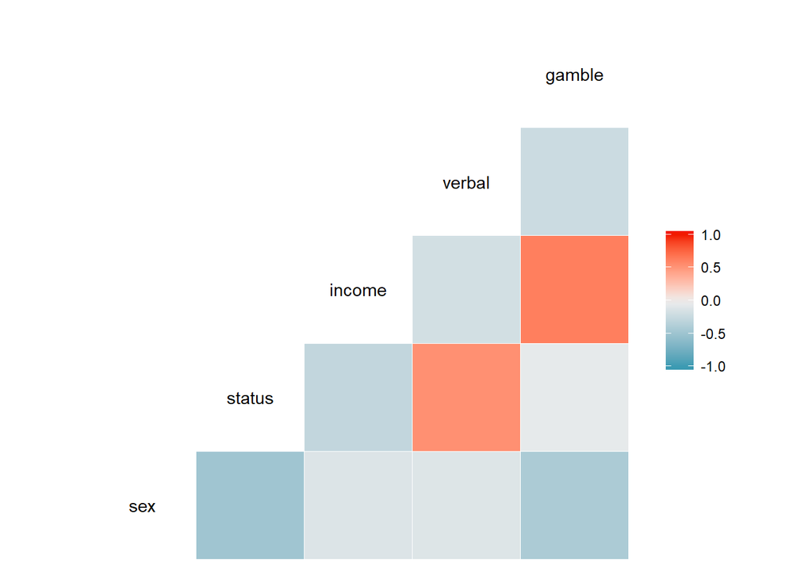

```r
ggcorr(teengamb)
```

## Question 1.3

The dataset prostate is from a study on 97 men with prostate cancer who were due to receive a radical prostatectomy. Make a numerical and graphical summary of the data as in the first question.

First, we load the data:

```r
data(prostate)
```

Next, we take a look at a summary of the data:

```r
summary(prostate)
```

```
##      lcavol           lweight           age             lbph
##  Min.   :-1.3471   Min.   :2.375   Min.   :41.00   Min.   :-1.3863
##  1st Qu.: 0.5128   1st Qu.:3.376   1st Qu.:60.00   1st Qu.:-1.3863
##  Median : 1.4469   Median :3.623   Median :65.00   Median : 0.3001
##  Mean   : 1.3500   Mean   :3.653   Mean   :63.87   Mean   : 0.1004
##  3rd Qu.: 2.1270   3rd Qu.:3.878   3rd Qu.:68.00   3rd Qu.: 1.5581
##  Max.   : 3.8210   Max.   :6.108   Max.   :79.00   Max.   : 2.3263
##       svi              lcp             gleason          pgg45
##  Min.   :0.0000   Min.   :-1.3863   Min.   :6.000   Min.   :  0.00
##  1st Qu.:0.0000   1st Qu.:-1.3863   1st Qu.:6.000   1st Qu.:  0.00
##  Median :0.0000   Median :-0.7985   Median :7.000   Median : 15.00
##  Mean   :0.2165   Mean   :-0.1794   Mean   :6.753   Mean   : 24.38
##  3rd Qu.:0.0000   3rd Qu.: 1.1786   3rd Qu.:7.000   3rd Qu.: 40.00
##  Max.   :1.0000   Max.   : 2.9042   Max.   :9.000   Max.   :100.00
##       lpsa
##  Min.   :-0.4308
##  1st Qu.: 1.7317
##  Median : 2.5915
##  Mean   : 2.4784
##  3rd Qu.: 3.0564
##  Max.   : 5.5829
```

Let’s take a look at the distributions of each of these variables:

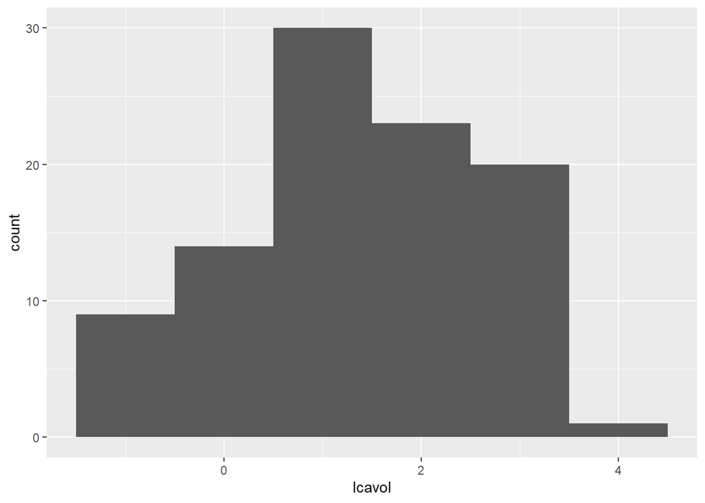

```r
ggplot(prostate, aes(lcavol)) + geom_histogram(binwidth = 1)
```

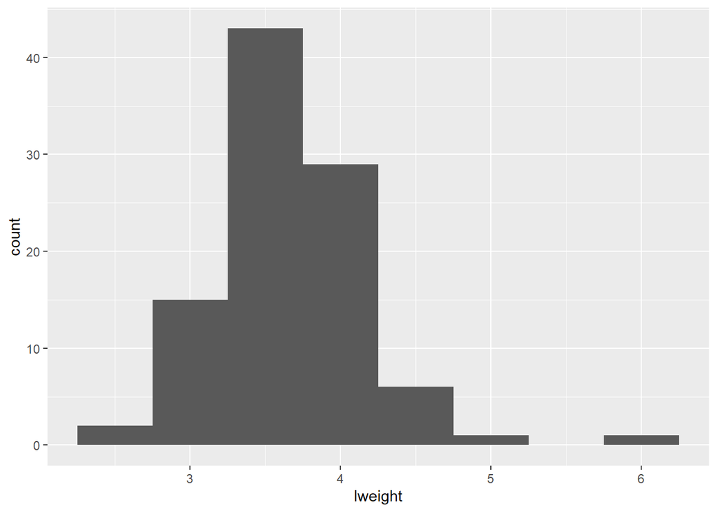

```r
ggplot(prostate, aes(lweight)) + geom_histogram(binwidth = 0.5)
```

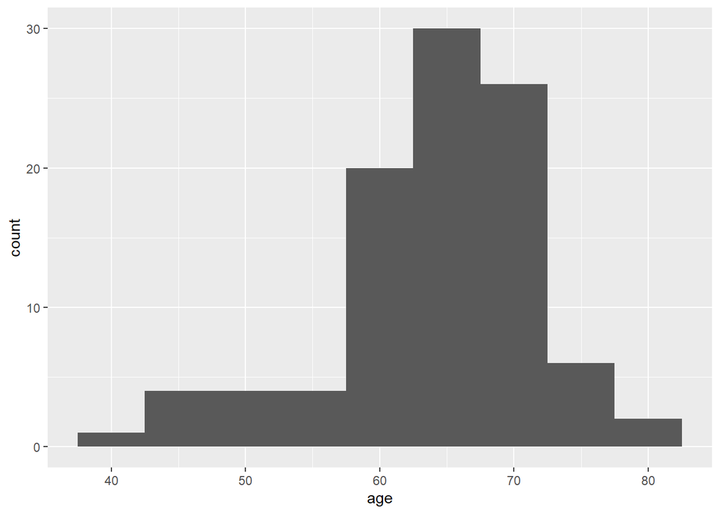

```r
ggplot(prostate, aes(age)) + geom_histogram(binwidth = 5)
```

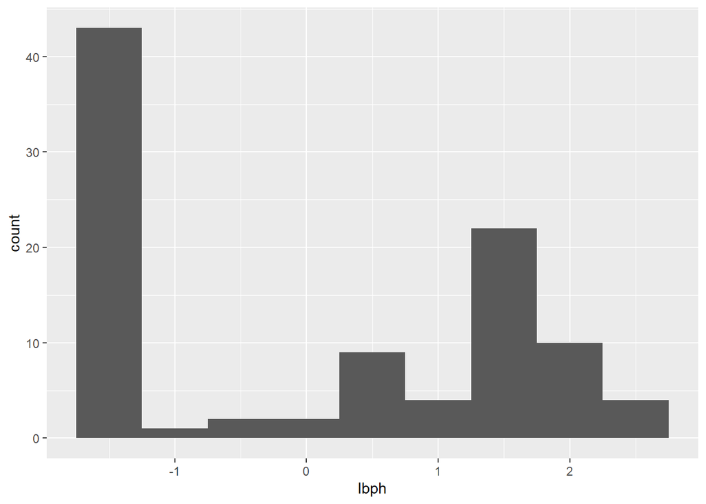

```r
ggplot(prostate, aes(lbph)) + geom_histogram(binwidth = 0.5)
```

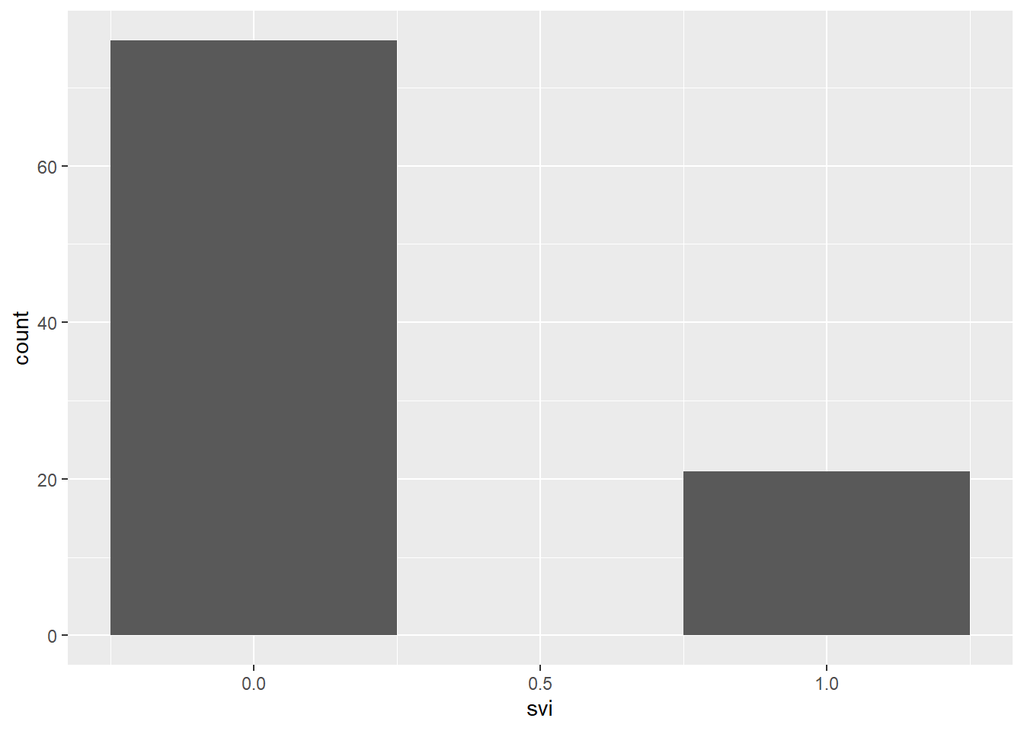

```r
ggplot(prostate, aes(svi)) + geom_histogram(binwidth = 0.5)
```

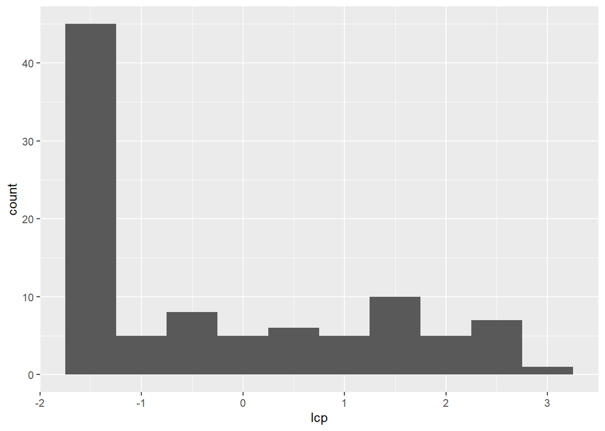

```r
ggplot(prostate, aes(lcp)) + geom_histogram(binwidth = 0.5)
```

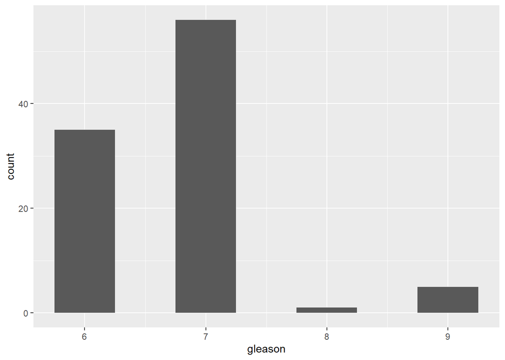

```r
ggplot(prostate, aes(gleason)) + geom_histogram(binwidth = 0.5)
```

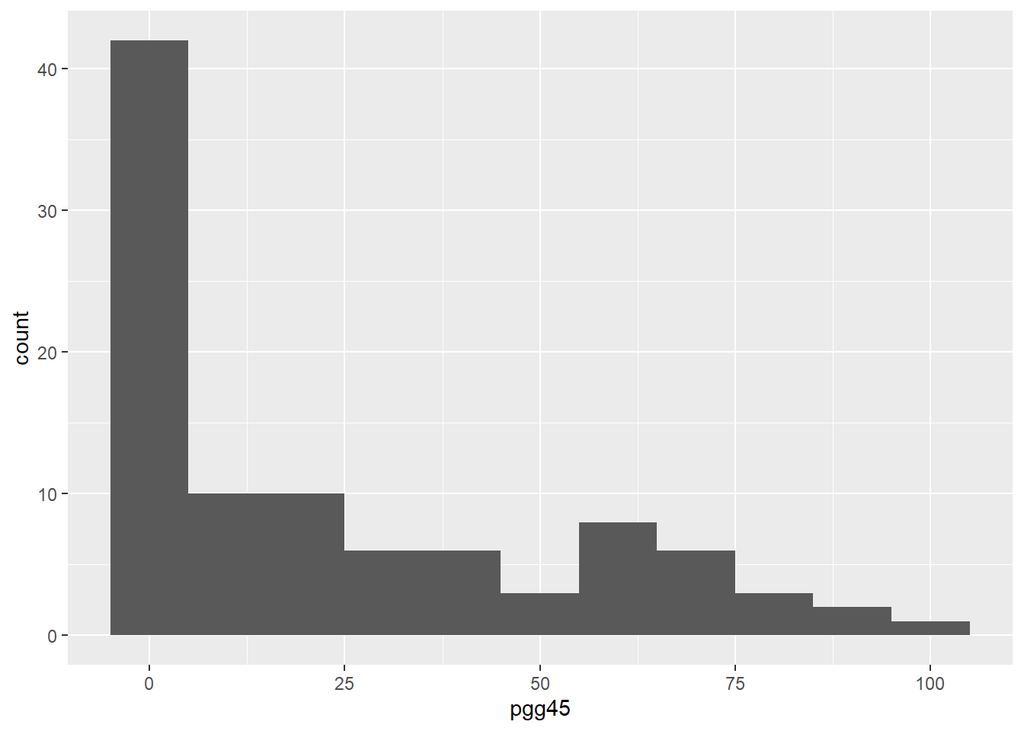

```r
ggplot(prostate, aes(pgg45)) + geom_histogram(binwidth = 10)
```

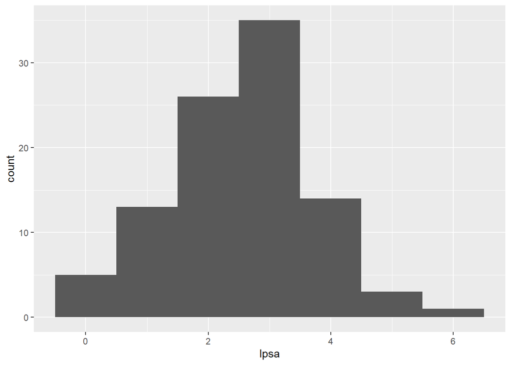

```r
ggplot(prostate, aes(lpsa)) + geom_histogram(binwidth = 1)
```

## Question 1.4

The dataset sat comes from a study entitled “Getting What You Pay For: The Debate Over Equity in Public School Expenditures.” Make a numerical and graphical summary of the data as in the first question.

```r
data(sat)
```

Next, we take a look at a summary of the data:

```r
summary(sat)
```

```
##      expend          ratio           salary          takers
##  Min.   :3.656   Min.   :13.80   Min.   :25.99   Min.   : 4.00
##  1st Qu.:4.882   1st Qu.:15.22   1st Qu.:30.98   1st Qu.: 9.00
##  Median :5.768   Median :16.60   Median :33.29   Median :28.00
##  Mean   :5.905   Mean   :16.86   Mean   :34.83   Mean   :35.24
##  3rd Qu.:6.434   3rd Qu.:17.57   3rd Qu.:38.55   3rd Qu.:63.00
##  Max.   :9.774   Max.   :24.30   Max.   :50.05   Max.   :81.00
##      verbal           math           total
##  Min.   :401.0   Min.   :443.0   Min.   : 844.0
##  1st Qu.:427.2   1st Qu.:474.8   1st Qu.: 897.2
##  Median :448.0   Median :497.5   Median : 945.5
##  Mean   :457.1   Mean   :508.8   Mean   : 965.9
##  3rd Qu.:490.2   3rd Qu.:539.5   3rd Qu.:1032.0
##  Max.   :516.0   Max.   :592.0   Max.   :1107.0
```

Let’s visualize the relationship between expenditure, salary, and takers vs SAT score.

- The relationship between expend and total score is weak and negative. Variability does not appear to be constant for all values of expend.
- The relationship between salary and total score is weak and negative.
- The relationship between takers and total score is strong and negative, and does not apear to be linear.

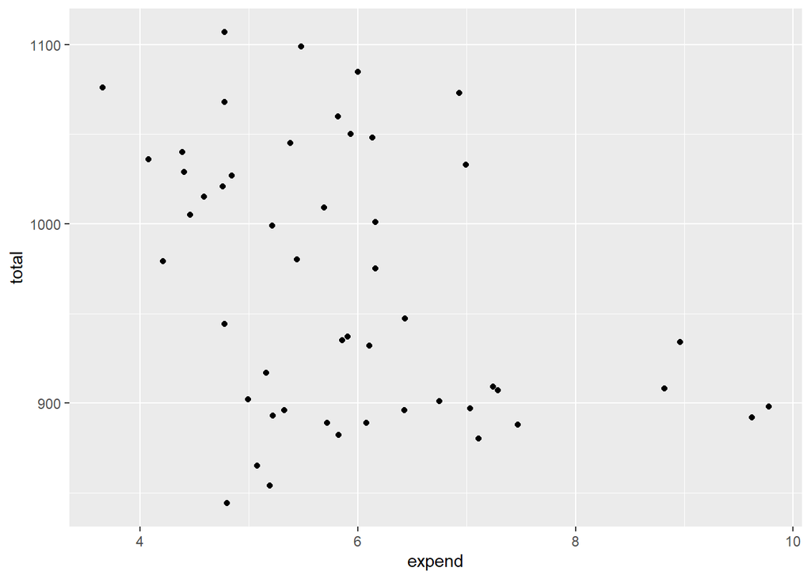

```r
ggplot(sat, aes(expend, total)) + geom_point()
```

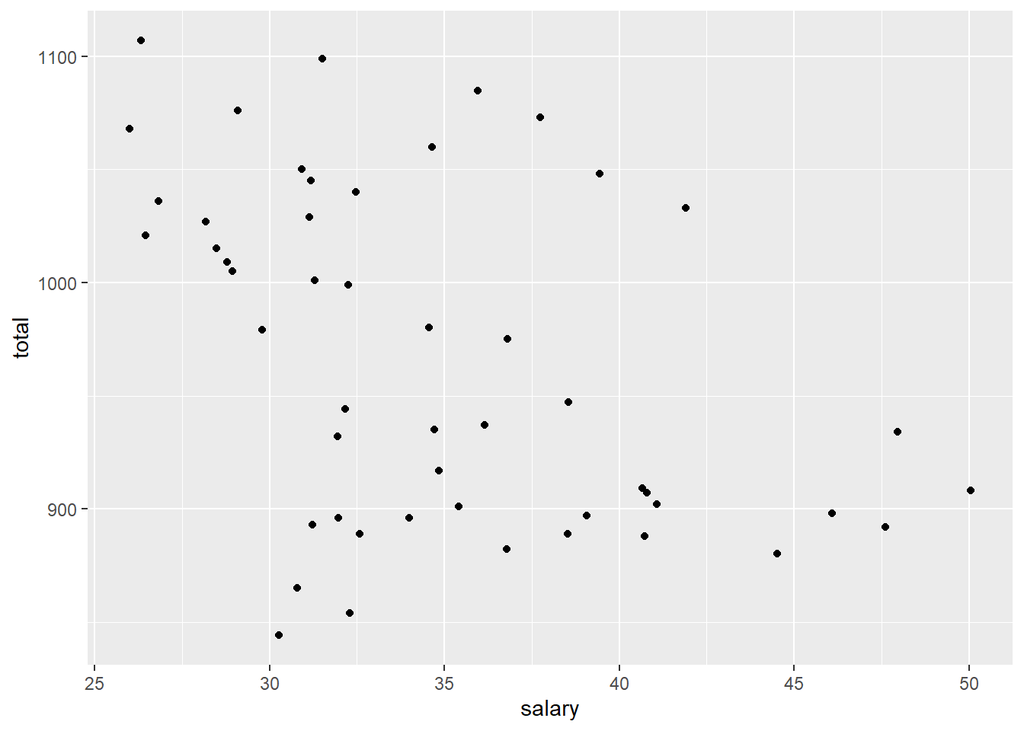

```r
ggplot(sat, aes(salary, total)) + geom_point()
```

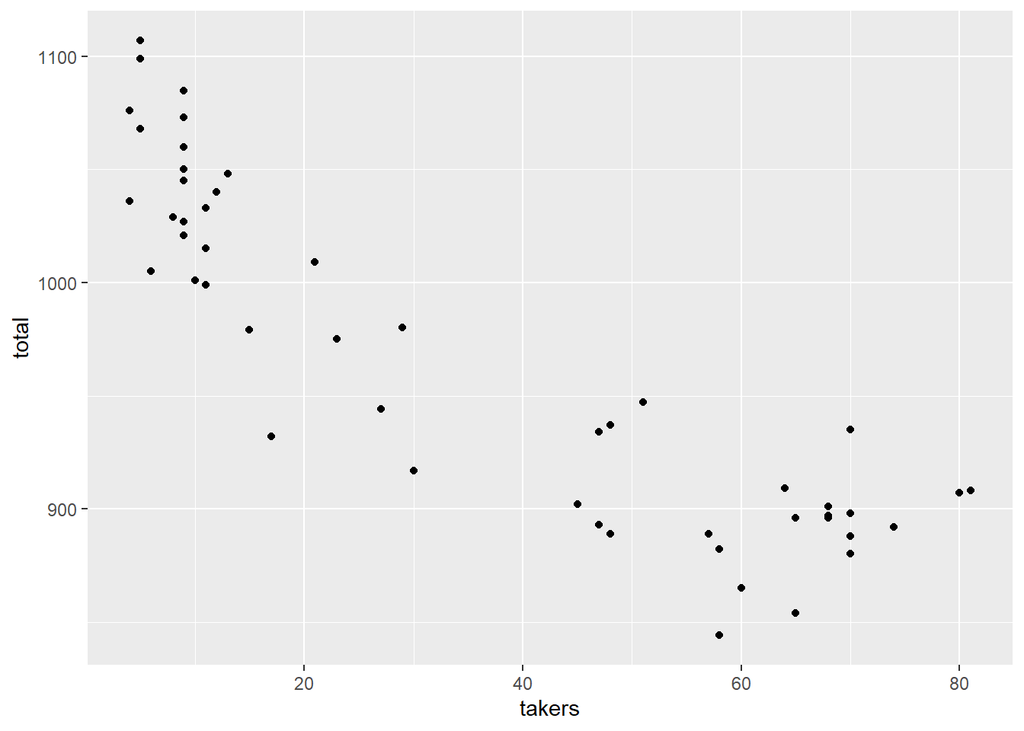

```r
ggplot(sat, aes(takers, total)) + geom_point()
```

## Question 1.5

The dataset divusa contains data on divorces in the United States from 1920 to 1996. Make a numerical and graphical summary of the data as in the first question.

```r
data(divusa)
```

Next, we take a look at a summary of the data:

```r
summary(divusa)
```

```
##       year         divorce        unemployed         femlab
##  Min.   :1920   Min.   : 6.10   Min.   : 1.200   Min.   :22.70
##  1st Qu.:1939   1st Qu.: 8.70   1st Qu.: 4.200   1st Qu.:27.47
##  Median :1958   Median :10.60   Median : 5.600   Median :37.10
##  Mean   :1958   Mean   :13.27   Mean   : 7.173   Mean   :38.58
##  3rd Qu.:1977   3rd Qu.:20.30   3rd Qu.: 7.500   3rd Qu.:47.80
##  Max.   :1996   Max.   :22.80   Max.   :24.900   Max.   :59.30
##     marriage          birth           military
##  Min.   : 49.70   Min.   : 65.30   Min.   : 1.940
##  1st Qu.: 61.90   1st Qu.: 68.90   1st Qu.: 3.469
##  Median : 74.10   Median : 85.90   Median : 9.102
##  Mean   : 72.97   Mean   : 88.89   Mean   :12.365
##  3rd Qu.: 80.00   3rd Qu.:107.30   3rd Qu.:14.266
##  Max.   :118.10   Max.   :122.90   Max.   :86.641
```

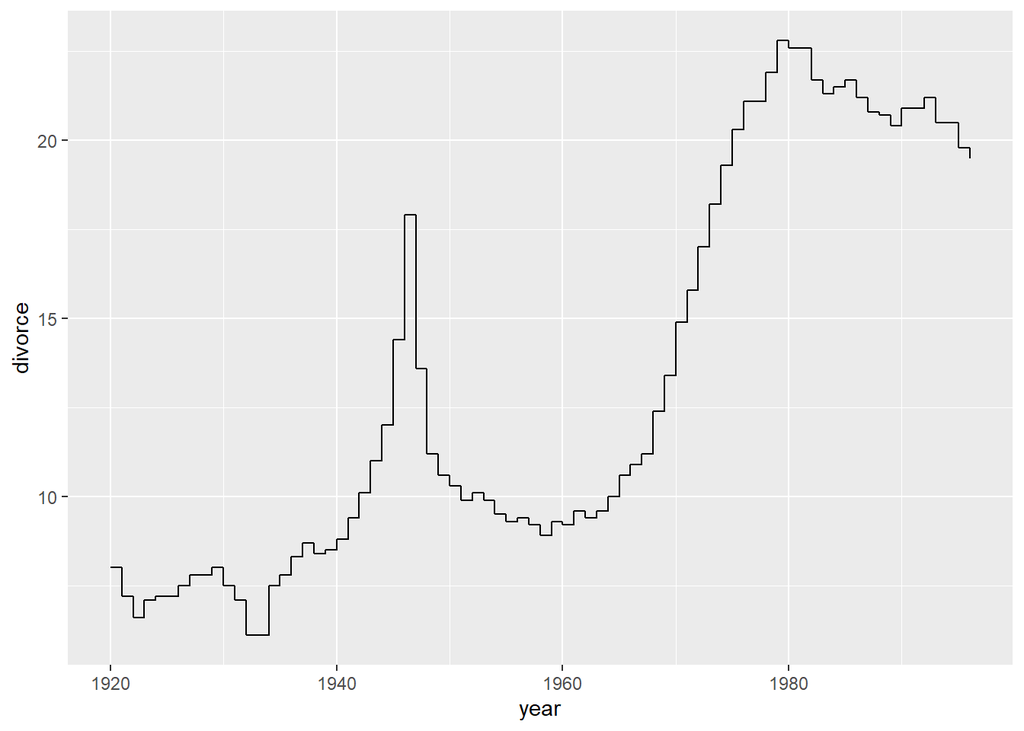

```r
ggplot(divusa, aes(year, divorce)) + geom_step(direction = "hv")
```

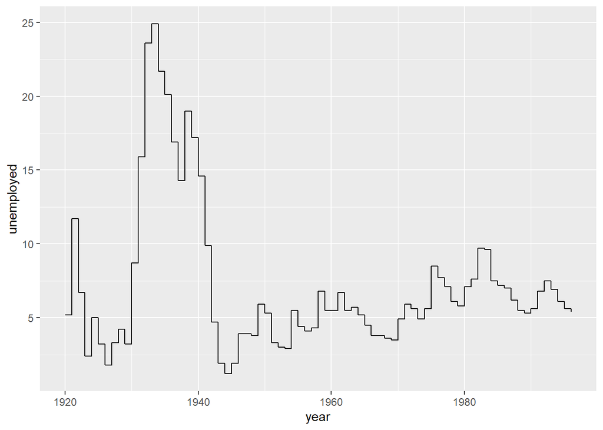

```r
ggplot(divusa, aes(year, unemployed)) + geom_step(direction = "hv")
```

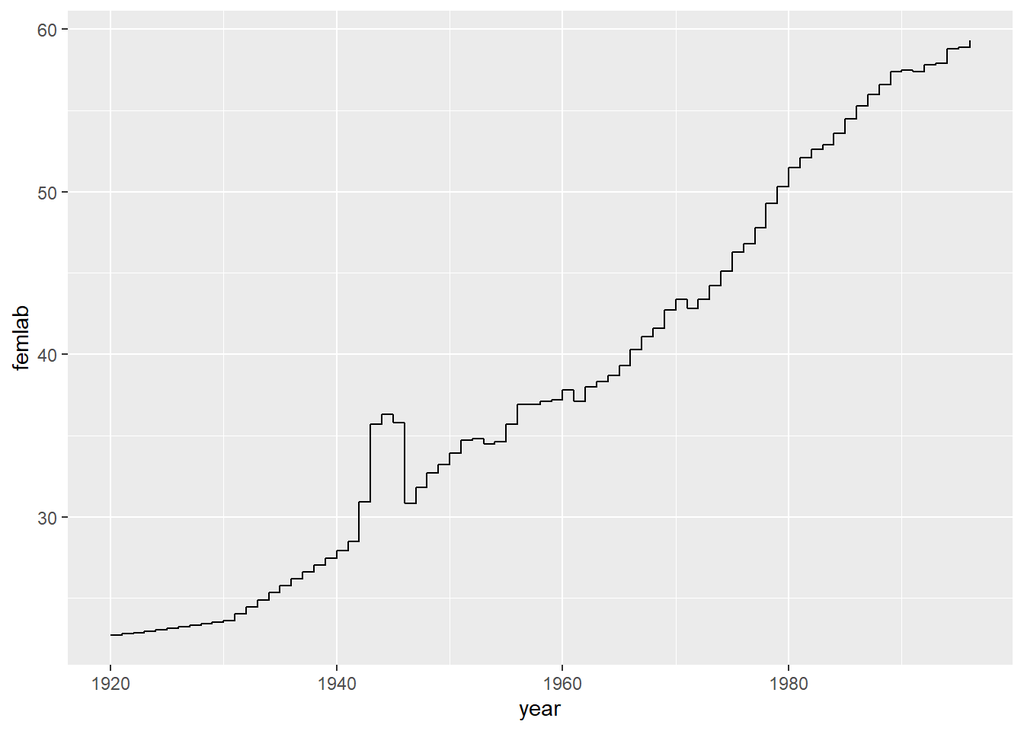

```r
ggplot(divusa, aes(year, femlab)) + geom_step(direction = "hv")
```

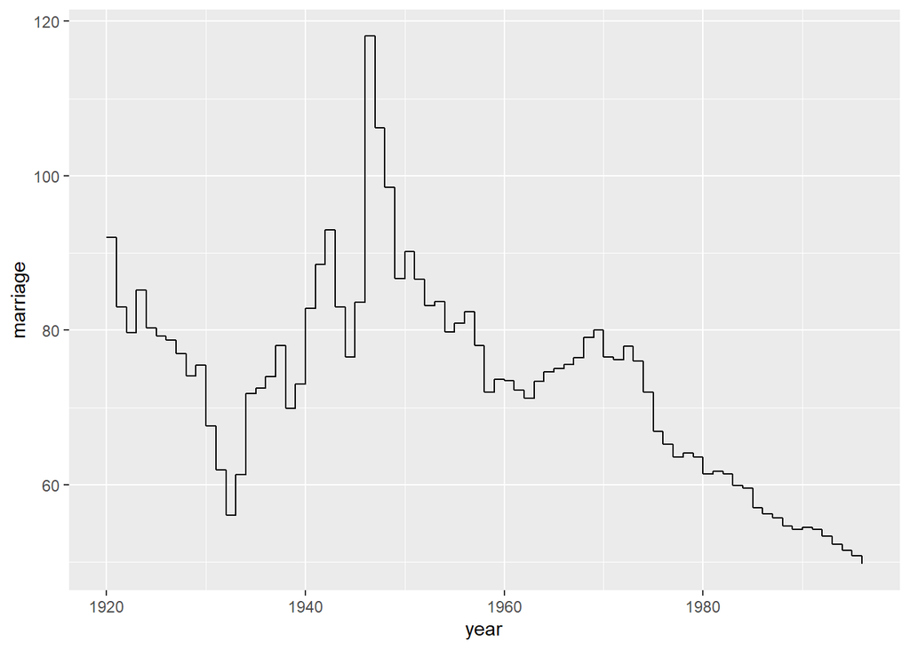

```r
ggplot(divusa, aes(year, marriage)) + geom_step(direction = "hv")
```

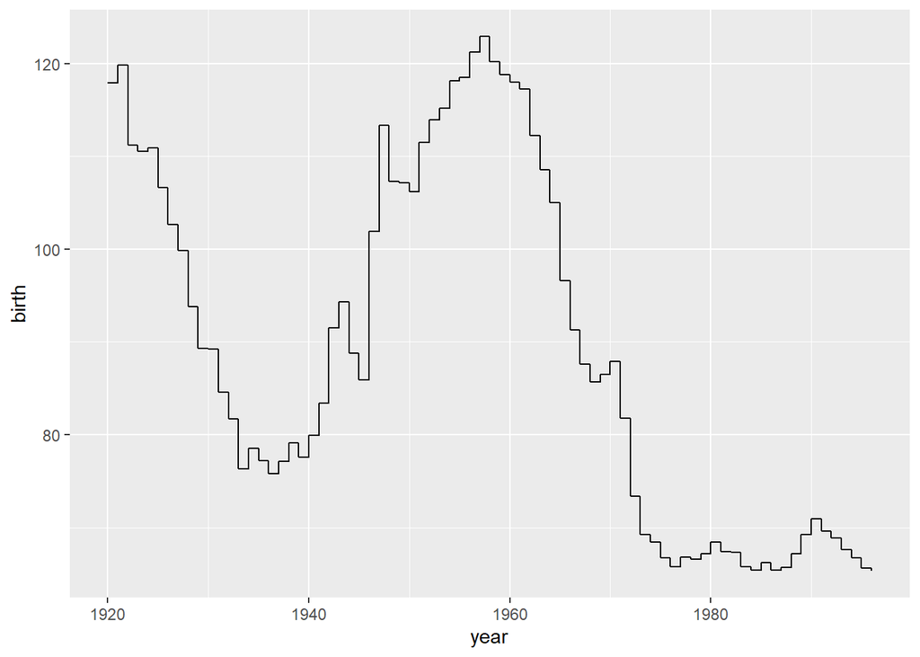

```r
ggplot(divusa, aes(year, birth)) + geom_step(direction = "hv")
```

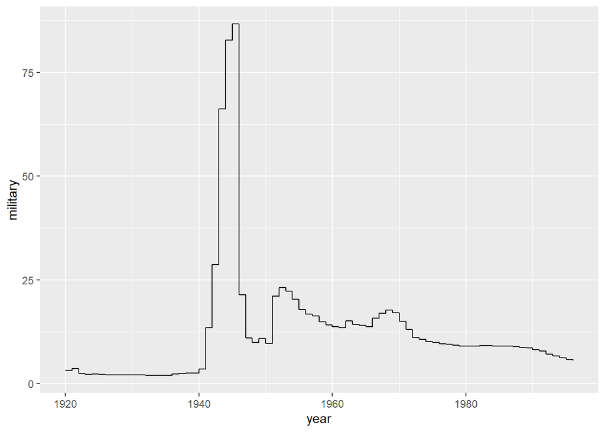

```r
ggplot(divusa, aes(year, military)) + geom_step(direction = "hv")
```

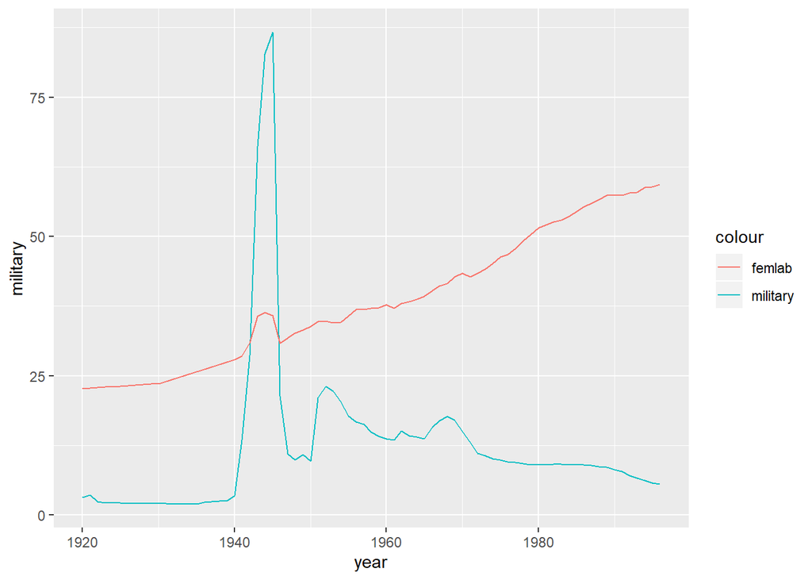

```r
ggplot(divusa, aes(year)) +
  geom_line(aes(y = military, colour = "military")) +
  geom_line(aes(y = femlab, colour = "femlab"))
```

Let’s look at the relationship between marriage, birth, and unemployement.

- When unemployment goes up, marriage and birth drop
- Marriage and birth are closely related except during 1950 - 1965

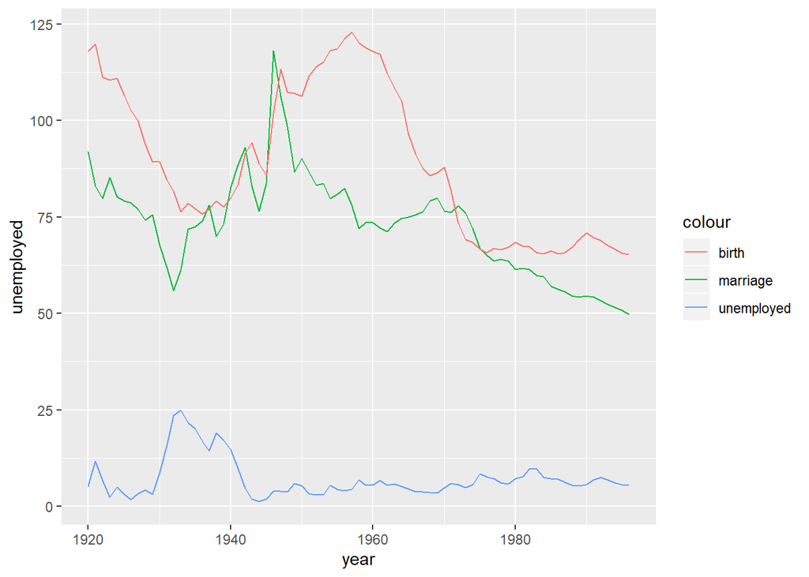

```r
ggplot(divusa, aes(year)) +
  geom_line(aes(y = unemployed, colour = "unemployed")) +
  geom_line(aes(y = marriage, colour = "marriage")) +
  geom_line(aes(y = birth, colour = "birth"))
```